# MATH 140 PreLab 1: Welcome to RStudio

Hitchman

9/1/2021

## Lab 1 Objectives

1. Input and import data in *RStudio*,
2. Determine summary statistics,
3. Present data visually, and
4. Use *R Markdown* to write a lab report.

## Pre-Lab Instructions

1. Read this document! I encourage you to work along with the examples in RStudio.

## Lab Report Instructions

Each group will submit one lab report. The report for this introductory lab consists entirely of written responses to the exercises provided in the lab. Each group will write their labe report using *R Markdown* in *RStudio*. A template markdown file will be provided.

**Golden Rule of Write-ups**: Place statistics in context using complete sentences.

**Example** Below are three solutions to a computational exercise; one solution is poor, one is better, and one is best.

*Exercise: For one week I keep track of the number of hours I study statistics each day. Here are the data: 3, 2.5, 1, 0, 1.5, 0, 2. Find the mean of these data.*

Three solutions:

1. “1.4.”
2. “The mean is 1.4.”
3. “This week I studied statistics an average of 1.4 hours per day.”

Solution 1 is poor. No context for this number is given in this answer, and the answer isn’t even a sentence. Solution 2 is better because it identifies 1.4 as a mean, and it is a complete sentence. However, the solution gives no conext for the statistic. What is this number the mean *of*? Without the context, the number has no *meaning* to the reader. Solution 3 is best. Full context is given for the statistic 1.4.

## 1. Input and Import Data

### Input data as a vector (ordered list) with `c( )`

> Use the `c()` function in RStudio to input an ordered list, called a *vector*.

Here ‘c’ stands for combine, or concatenate.

```r
colors <- c("dodgerblue","orange","gold")
numbers <- c(8,4,1,0)
```

Often we give a name to a vector. Above, I have defined a vector of words (colors recognized by R), giving it the name *colors*. I have also defined the vector *numbers*, consisting of my four favorite numbers.

Consider this ordered list of numbers:

20, 24, 24, 21, 27, 37, 31, 37, 45, 38, 39, 42, 51, 46, 36, 34, 39, 32, 32, 39, 39, 12

Values like this, when given context, form a data set. These values list the wins by the Linfield Softball season for the seasons from 1999 to 2020. I input this list, and give it the name *cats*:

```r
cats <- c(20, 24, 24, 21, 27, 37, 31, 37, 45, 38, 39, 42, 51, 46, 36, 34, 39, 32, 32, 39, 39, 12)
```

What is the mean of these values?

```r
mean(cats)
```

```
## [1] 33.86364
```

### Import a .csv data file from the web

The world is awash in data, and a common file type is the .csv file, which stands for ‘comma separated values’. With RStudio, data is at our fingertips!

> Import a .csv file from the web

```r
wildcats <- read.csv("https://www.mphitchman.com/stats/data/softball.csv")
```

The above code imported the data file called ‘softball.csv’ from our course resource page. What does this data file look like? Here’s a look:

```r
wildcats
```

```
##    Year           Coach  W  L T District NCAA
## 1  1999     Laura Kenow 20 17 0      3rd
## 2  2000     Laura Kenow 24 10 0      4th
## 3  2001     Laura Kenow 24 17 0      2nd
## 4  2002 Jackson Vaughan 21 17 0      3rd
## 5  2003 Jackson Vaughan 27 11 0      2nd
## 6  2004 Jackson Vaughan 37  9 0      1st
## 7  2005 Jackson Vaughan 31  9 1      1st
## 8  2006 Jackson Vaughan 37 11 0      1st  4th
## 9  2007 Jackson Vaughan 45  7 0      1st  1st
## 10 2008 Jackson Vaughan 38  6 0      1st
## 11 2009 Jackson Vaughan 39  6 0      1st
## 12 2010 Jackson Vaughan 42  7 0      1st  2nd
## 13 2011 Jackson Vaughan 51  3 0      1st  1st
## 14 2012 Jackson Vaughan 46  7 0      1st  2nd
## 15 2013 Jackson Vaughan 36  8 0      1st
## 16 2014 Jackson Vaughan 34  9 0      1st
## 17 2015 Jackson Vaughan 39 15 0      4th  3rd
## 18 2016 Jackson Vaughan 32 16 0  2nd tie
## 19 2017 Jackson Vaughan 32 10 0      2nd
## 20 2018 Jackson Vaughan 39 10 0  1st tie
## 21 2019 Jackson Vaughan 39  8 1      1st
## 22 2020 Jackson Vaughan 12  2 0      DNF
```

`wildcats` is an example of a data matrix, also called a data frame. The rows of a data matrix are called *observations*, the columns give the *variables*. In `wildcats` each row is a season, and the variables include the year, the coach, wins, losses, and placement in district and nationals.

The values in the *W* column of `wildcats’ exactly matches the list *cats* we created above. To view this column we can enter the following:

```r
wildcats$W
```

```
##  [1] 20 24 24 21 27 37 31 37 45 38 39 42 51 46 36 34 39 32 32 39 39 12
```

Note: to view a column we type the name of the data frame followed by a dollar sign ($) followed by the name of the column.

## Descriptive Statistics in RStudio

Here are some common functions we can use to explore and summarize a data set.

| function | description |
| --- | --- |
| `length()` | returns the size of the data set entered in the parentheses |
| `mean()` | returns the mean of the data set |
| `median()` | returns the median |
| `max()` | returns the maximum of the data |
| `min()` | returns the min |
| `sum()` | returns the sum of the data |
| `var()` | returns the variance of the data |
| `sd()` | returns the standard deviation of the data |
| `summary()` | returns 6 statistics: min, Q1, median, mean, Q3, max |
| `fivenum()` | returns the 5 number summary: min Q1 median Q3 max |
| `table()` | returns the frequency of each unique value of the data |

We can apply these functions to a vector we have entered, as we did above by computing `mean(cats)`, and we can apply these functions to columns of data frames.

```r
mean(wildcats$L) # the losses column of the dataframe `wildcats`
```

```
## [1] 9.772727
```

**Help Menu** RStudio has very good documentation about its commands in the help menu. This menu can be found in the lower right pane by clicking on the Help tab. Then you can search for a particular item. For instance, in the help menu try searching for *sd*, the standard deviation function.

Now, back to Linfield Softball!

How many game did Linfield softball win between 1999 and 2020?

```r
sum(wildcats$W)
```

```
## [1] 745
```

The five number summary?

```r
fivenum(wildcats$W)
```

```
## [1] 12.0 27.0 36.5 39.0 51.0
```

What sorts of finishes in Districts has Linfield Softball enjoyed?

```r
table(wildcats$District)
```

```
##
##     1st 1st tie     2nd 2nd tie     3rd     4th     DNF
##      12       1       3       1       2       2       1
```

Wow! First (or tied for first) in 13 of the 22 seasons!

### Basic data management (very brief sampler)

#### Extracting particular elements in a list

```r
x <- c(10,12,14,16,9,13)
x[3] # returns the third element in the list.
```

```
## [1] 14
```

#### Doing math with data sets and functions

We can compute the mean of a data set the ``old-fashioned’ way, adding up the values and dividing by the number of them:

```r
x <- c(10,12,8,7,14,25,21)
sum(x)/length(x)
```

```
## [1] 13.85714
```

But, really, why would we, when we can use the `mean()` command, as we did previously? The point of this first example is to demonstrate that we can do *math* with these commands.

Here’s another example. Can you interpret the following code? What type of object is the output?

```r
x <- c(10,12,17)
x-4
```

```
## [1]  6  8 13
```

ANSWER: R subtracted 4 from each value in the vector `x` and returned a new vector (with three elements).

How about this one?

```r
x <- c(10,12,17)
xbar <- mean(x)
d <- (x - mean(x))^2
```

`x` is a vector of three values, `xbar` is the mean of the values in `x`. So what is `d`?

```r
d
```

```
## [1]  9  1 16
```

d is aslo a vector of three values, obtained from `x` by subtracting each element of `x` by `xbar` and then squaring the difference. Hold on! Then this…

```r
sum(d)/(length(d)-1)
```

```
## [1] 13
```

… must be, the variance of `x`? Let’s check:

```r
var(x)
```

```
## [1] 13
```

Yup.

## Basic Data visualization

A boxplot is a visual representation of the 5 number summary, and R loves to make them!

### Boxplots

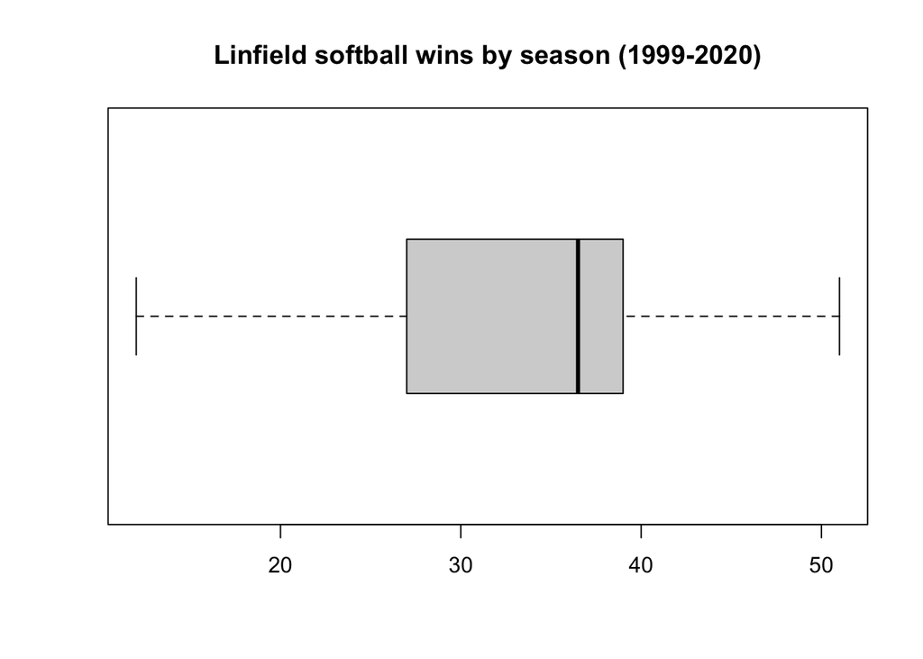

```r
boxplot(wildcats$W,
        main="Linfield softball wins by season (1999-2020)",
        horizontal = TRUE)
```

### Stem-and-leaf plots

```r
stem(cats)
```

```
##
##   The decimal point is 1 digit(s) to the right of the |
##
##   1 | 2
##   2 | 01447
##   3 | 122467789999
##   4 | 256
##   5 | 1
```

with split stems:

```r
stem(cats, scale = 2)
```

```
##
##   The decimal point is 1 digit(s) to the right of the |
##
##   1 | 2
##   1 |
##   2 | 0144
##   2 | 7
##   3 | 1224
##   3 | 67789999
##   4 | 2
##   4 | 56
##   5 | 1
```

### Stacked dot plot

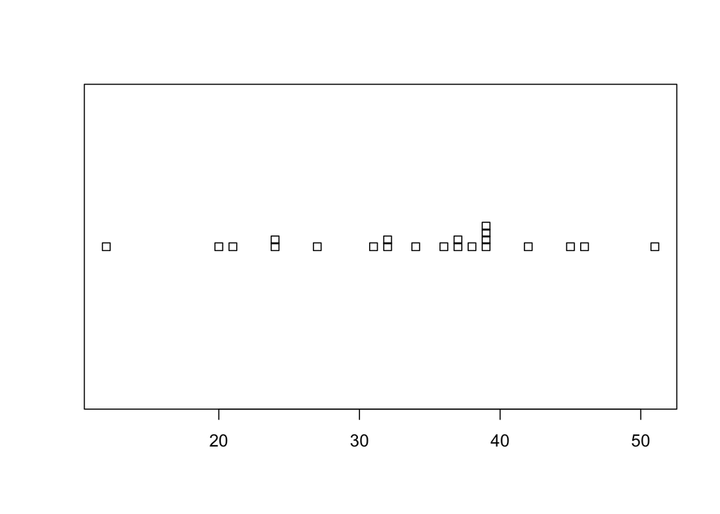

```r
stripchart(cats, method = "stack")
```

And we can make a stacked dot plot look fancier by adding a title, some color, axis labels, etc

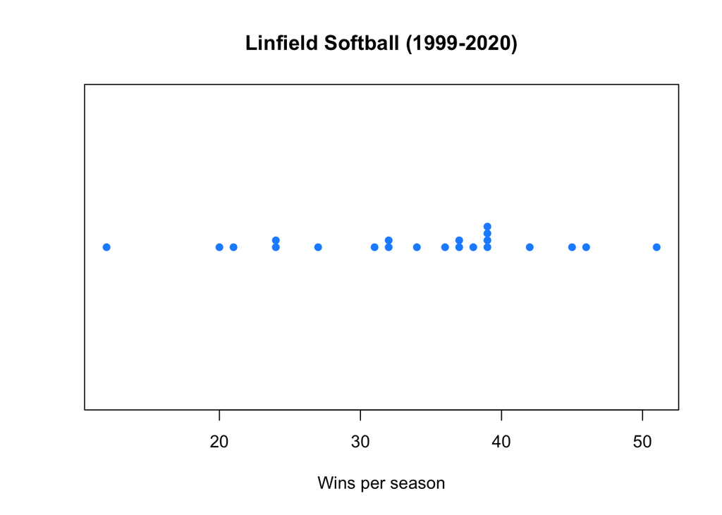

```r
stripchart(wildcats$W,
           main="Linfield Softball (1999-2020)", # title
           xlab="Wins per season", #x-axis label
           ylab="", #y axis label (empty for this chart)
           method = "stack", #
           col="dodgerblue", #dot color
           pch=16, # dot shape and filling
           )
```